# Analysis of Student Academic Performance

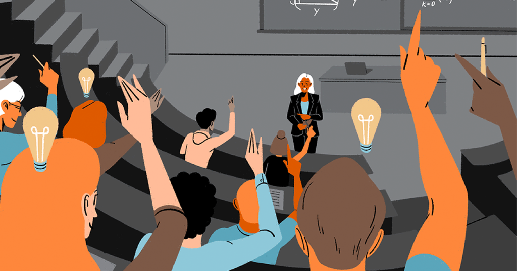

## 1. Introduction

When we talk about student academic performance, having a good teacher or a motivated student is only a small portion of what ultimately contributes to a student’s success. There are various factors which influence student performance, and we aim at identifying those factors in this project.

#### 1.1 Research Question

What are the major factors that influence student academic performance?

## 2. Methods

- Data Preparation
- Data Cleaning
- Exploratory Data Analysis

### 2.1 Data Preparation

- For this research, we will use 1 dataset downloaded in csv format from kaggle website link [here](https://www.kaggle.com/datasets/whenamancodes/students-performance-in-exams).
- This dataset consists of the marks secured by the students in 3 subjects: Mathematics, Reading and Writing
- Its attributes are described below:

[output not shown]

Now let's prepare the data by loading it into python

```python
# Import needed libraries
import pandas as pd
import seaborn as sns
import matplotlib.pyplot as plt
%matplotlib inline

# Load dataset
student_grades = pd.read_csv('exams.csv')
print(student_grades.shape)
student_grades.head()
```

```
(1000, 8)
```

|  | gender | race/ethnicity | parental level of education | lunch | test preparation course | math score | reading score | writing score |
| --- | --- | --- | --- | --- | --- | --- | --- | --- |
| 0 | male | group A | high school | standard | completed | 67 | 67 | 63 |
| 1 | female | group D | some high school | free/reduced | none | 40 | 59 | 55 |
| 2 | male | group E | some college | free/reduced | none | 59 | 60 | 50 |
| 3 | male | group B | high school | standard | none | 77 | 78 | 68 |
| 4 | male | group E | associate's degree | standard | completed | 78 | 73 | 68 |

### 2.2 Data Cleaning

- Renaming columns to more meaningful names
- Creating a new column that calculates the average score of each student and another column that classify the average score according to the grading system given below

| Score range | Grade | Qualification |
| --- | --- | --- |
| 95-100 | O | Outstanding |
| 81-94 | A | Very Good |
| 71-80 | B | Good |
| 51-70 | C | Average |
| 0-50 | F | Fail |

- Assign the appropriate data types to each features
- Checking for missing & duplicate values

```python
# Renaming columns

new_names = {'race/ethnicity': 'race',
             'parental level of education' : 'parent_education_level',
             'lunch': 'lunch_type',
             'test preparation course' : 'test_prep_course',
             'math score' : 'maths_score',
             'reading score' : 'reading_score',
             'writing score' : 'writing_score'
            }

student_grades.rename(columns = new_names, inplace = True)
student_grades.head()
```

|  | gender | race | parent_education_level | lunch_type | test_prep_course | maths_score | reading_score | writing_score |
| --- | --- | --- | --- | --- | --- | --- | --- | --- |
| 0 | male | group A | high school | standard | completed | 67 | 67 | 63 |
| 1 | female | group D | some high school | free/reduced | none | 40 | 59 | 55 |
| 2 | male | group E | some college | free/reduced | none | 59 | 60 | 50 |
| 3 | male | group B | high school | standard | none | 77 | 78 | 68 |
| 4 | male | group E | associate's degree | standard | completed | 78 | 73 | 68 |

```python
# check the data types of columns

student_grades.dtypes
```

```
gender                    object
race                      object
parent_education_level    object
lunch_type                object
test_prep_course          object
maths_score                int64
reading_score              int64
writing_score              int64
dtype: object
```

```python
# create a new column that calculates the average score of each student
student_grades['overall_score'] = round((student_grades['maths_score'] + student_grades['reading_score'] + student_grades['writing_score'])/3,2)

# create a new column that classifies the average score of each student
def classify(score):
    if (score >= 95):return 'O'
    if (score >= 81):return 'A'
    if (score >= 71):return 'B'
    if (score >= 51):return 'C'
    else: return 'F'
student_grades["overall_grade"] = student_grades.apply(lambda x : classify(x["overall_score"]), axis=1)

# change the datatype of the categorical features from string/object to category
for i in student_grades.columns:
    if student_grades[i].dtype == 'object':
        student_grades[i] = pd.Categorical(student_grades[i])

print(student_grades.dtypes)
student_grades.head()
```

```
gender                    category
race                      category
parent_education_level    category
lunch_type                category
test_prep_course          category
maths_score                  int64
reading_score                int64
writing_score                int64
overall_score              float64
overall_grade             category
dtype: object
```

|  | gender | race | parent_education_level | lunch_type | test_prep_course | maths_score | reading_score | writing_score | overall_score | overall_grade |
| --- | --- | --- | --- | --- | --- | --- | --- | --- | --- | --- |
| 0 | male | group A | high school | standard | completed | 67 | 67 | 63 | 65.67 | C |
| 1 | female | group D | some high school | free/reduced | none | 40 | 59 | 55 | 51.33 | C |
| 2 | male | group E | some college | free/reduced | none | 59 | 60 | 50 | 56.33 | C |
| 3 | male | group B | high school | standard | none | 77 | 78 | 68 | 74.33 | B |
| 4 | male | group E | associate's degree | standard | completed | 78 | 73 | 68 | 73.00 | B |

```python
# Checking for missing values
student_grades.info()
```

```
<class 'pandas.core.frame.DataFrame'>
RangeIndex: 1000 entries, 0 to 999
Data columns (total 10 columns):
 #   Column                  Non-Null Count  Dtype
---  ------                  --------------  -----
 0   gender                  1000 non-null   category
 1   race                    1000 non-null   category
 2   parent_education_level  1000 non-null   category
 3   lunch_type              1000 non-null   category
 4   test_prep_course        1000 non-null   category
 5   maths_score             1000 non-null   int64
 6   reading_score           1000 non-null   int64
 7   writing_score           1000 non-null   int64
 8   overall_score           1000 non-null   float64
 9   overall_grade           1000 non-null   category
dtypes: category(6), float64(1), int64(3)
memory usage: 38.2 KB
```

```python
# Checking for duplicate values
student_grades[student_grades.duplicated()]
```

|  | gender | race | parent_education_level | lunch_type | test_prep_course | maths_score | reading_score | writing_score | overall_score | overall_grade |
| --- | --- | --- | --- | --- | --- | --- | --- | --- | --- | --- |
| 825 | male | group E | associate's degree | standard | completed | 100 | 100 | 100 | 100.0 | O |

###### Handling Duplicate Values

This data contain no missing value, however we noticed 1 duplicate value which will not be removed from the dataset, because we can’t say for sure if the row is actually duplicated since each row cannot be uniquely identified by a unique identifier (e.g student id), and it may just be 2 students who have similar features.

### 2.3 Exploratory Data Analysis

- Summary Statistics
- Data Visualization

### 2.3.1 Summary Statistics

```python
# Summarize the numeric variables
student_grades.describe()
```

|  | maths_score | reading_score | writing_score | overall_score |
| --- | --- | --- | --- | --- |
| count | 1000.000000 | 1000.000000 | 1000.000000 | 1000.000000 |
| mean | 66.396000 | 69.002000 | 67.738000 | 67.712000 |
| std | 15.402871 | 14.737272 | 15.600985 | 14.514123 |
| min | 13.000000 | 27.000000 | 23.000000 | 21.670000 |
| 25% | 56.000000 | 60.000000 | 58.000000 | 58.585000 |
| 50% | 66.500000 | 70.000000 | 68.000000 | 67.330000 |
| 75% | 77.000000 | 79.000000 | 79.000000 | 78.330000 |
| max | 100.000000 | 100.000000 | 100.000000 | 100.000000 |

### 2.3.2 Data Visualization

Let's visualize how each column is distributed in the data

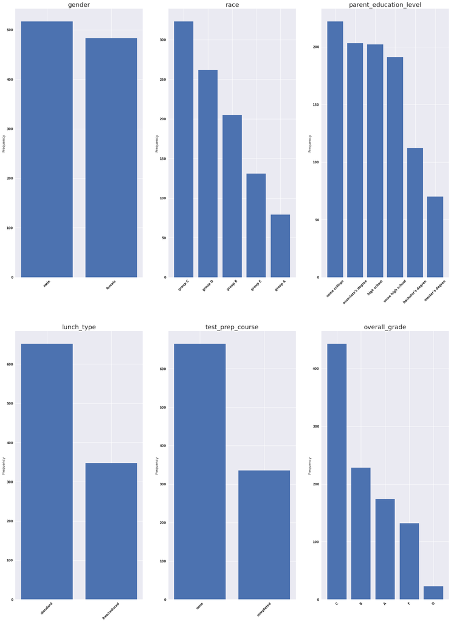

```python
# plot categorical variables
cat_columns = ['gender', 'race', 'parent_education_level', 'lunch_type', 'test_prep_course', 'overall_grade']
ncols = len(cat_columns)//3
plt.figure(figsize =(25, 35))
for index,col in enumerate(cat_columns):
    plt.subplot(ncols,3,index+1)
    var = student_grades[col]

    varValue = var.value_counts()

    plt.bar(varValue.index, varValue)
    plt.xticks(varValue.index, varValue.index.values,rotation=45)
    plt.ylabel("Frequency")
    #plt.title(col)
    plt.title(col, fontdict={'fontsize': 20})
plt.show()
```

#### Grades Correlation

Let's visualize the correlation among students' mathematics, reading, writing and overall scores.

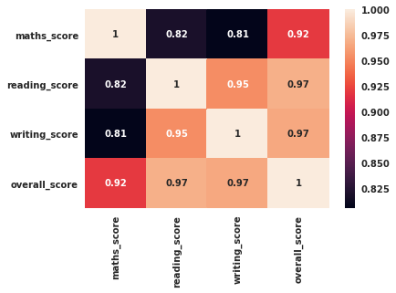

```python
sns.heatmap(student_grades.corr(),annot=True)
```

There exist strong positive correlation among the scores.

Now, let's visualize how each column is distributed by student scores and grades so as to know the major factors that influence student performance.

#### Grade Distribution by Gender

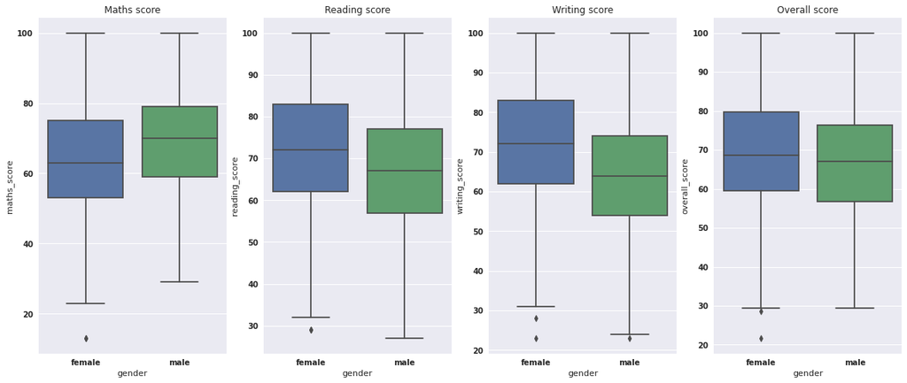

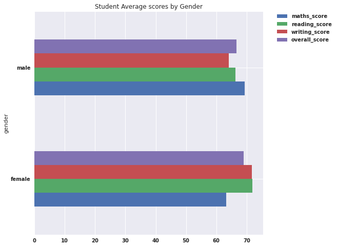

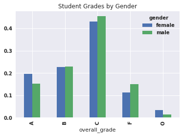

```python
gender = student_grades["gender"].value_counts()
v=student_grades.groupby('gender').maths_score.mean()

# boxplot of grades by gender
plt.figure(figsize =(20, 8))
plt.subplot(1,4,1)
sns.boxplot(x='gender', y='maths_score', data=student_grades)
plt.title("Maths score")
plt.subplot(1,4,2)
sns.boxplot(x='gender', y='reading_score', data=student_grades)
plt.title("Reading score")
plt.subplot(1,4,3)
sns.boxplot(x='gender', y='writing_score', data=student_grades)
plt.title("Writing score")
plt.subplot(1,4,4)
sns.boxplot(x='gender', y='overall_score', data=student_grades)
plt.title("Overall score")
plt.show()

# barplot of grades by gender
student_grades.groupby('gender').agg('mean').plot(kind='barh',figsize=(8,8))
plt.legend(bbox_to_anchor=(1.05, 1), loc=2, borderaxespad=0.)
plt.title("Student Average scores by Gender")
plt.show()

plt.figure(figsize =(10, 4))
pd.crosstab(student_grades.overall_grade, student_grades.gender, normalize="columns").plot(kind="bar")
plt.title("Student Grades by Gender")
plt.show()
```

From the above visuals we infer:

- The Average Math Score of Females is less than that of Males while females has the highest average score in terms of reading, writing, and the final score (average score of the 3 subject).
- Majority of students received C grade followed by B
- More female students performed outstandingly than male by earning an "O"
- More number of boys had a failing grade "F" than female

#### Grade Distribution by Race or Ethnicity

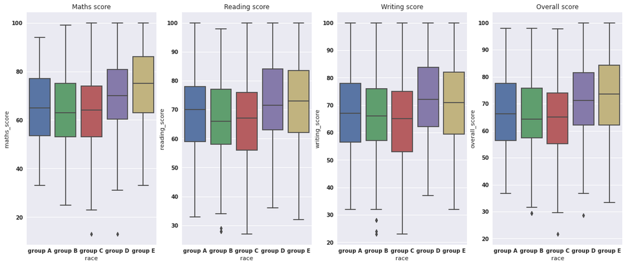

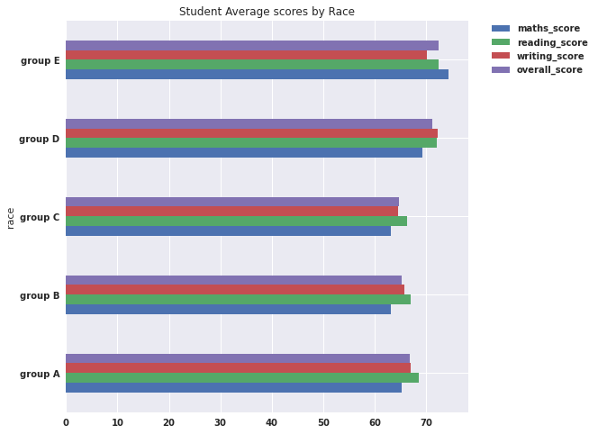

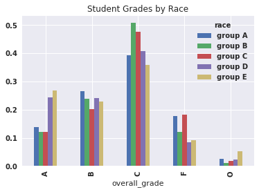

```python
# boxplot of grades by race
plt.figure(figsize =(20, 8))
plt.subplot(1,4,1)
sns.boxplot(x='race', y='maths_score', data=student_grades)
plt.title("Maths score")
plt.subplot(1,4,2)
sns.boxplot(x='race', y='reading_score', data=student_grades)
plt.title("Reading score")
plt.subplot(1,4,3)
sns.boxplot(x='race', y='writing_score', data=student_grades)
plt.title("Writing score")
plt.subplot(1,4,4)
sns.boxplot(x='race', y='overall_score', data=student_grades)
plt.title("Overall score")
plt.show()

# barplot of grades by race
student_grades.groupby('race').agg('mean').plot(kind='barh',figsize=(8,8))
plt.legend(bbox_to_anchor=(1.05, 1), loc=2, borderaxespad=0.)
plt.title("Student Average scores by Race")
plt.show()

plt.figure(figsize =(10, 4))
pd.crosstab(student_grades.overall_grade, student_grades.race, normalize="columns").plot(kind="bar")
plt.title("Student Grades by Race")
plt.show()
```

Performance of Group E is the best among all followed by D.

#### Grade Distribution by Education Level of Parents

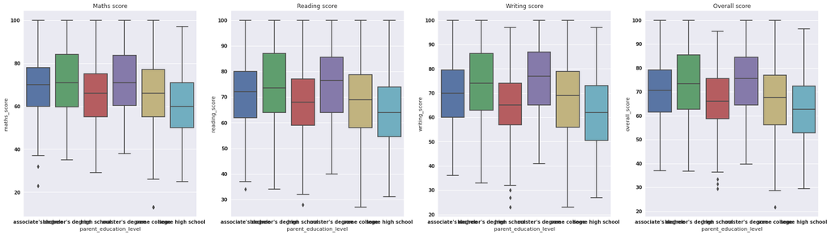

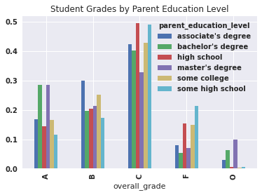

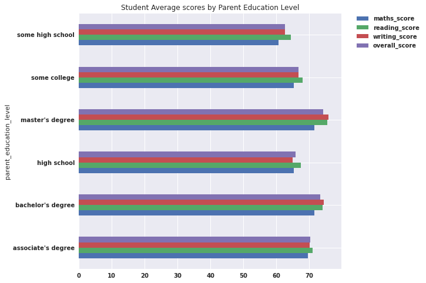

```python
# boxplot of grades by parent education level
plt.figure(figsize =(30, 8))
plt.subplot(1,4,1)
sns.boxplot(x='parent_education_level', y='maths_score', data=student_grades)
plt.title("Maths score")
plt.subplot(1,4,2)
sns.boxplot(x='parent_education_level', y='reading_score', data=student_grades)
plt.title("Reading score")
plt.subplot(1,4,3)
sns.boxplot(x='parent_education_level', y='writing_score', data=student_grades)
plt.title("Writing score")
plt.subplot(1,4,4)
sns.boxplot(x='parent_education_level', y='overall_score', data=student_grades)
plt.title("Overall score")
plt.show()

# barplot of grades by parent education level
plt.figure(figsize =(15, 4))
pd.crosstab(student_grades.overall_grade, student_grades.parent_education_level, normalize="columns").plot(kind="bar")
#plt.legend(bbox_to_anchor=(1.05, 1), loc=2, borderaxespad=0.)
plt.title("Student Grades by Parent Education Level")
plt.show()

student_grades.groupby('parent_education_level').agg('mean').plot(kind='barh',figsize=(8,8))
plt.legend(bbox_to_anchor=(1.05, 1), loc=2, borderaxespad=0.)
plt.title("Student Average scores by Parent Education Level")
plt.show()
```

- Students whose parents have a Master's & Bachelor's Degree have higher Performance compared to students whose parent have lower education level.
- Students whose parents have the least education background (some High school or High school) had the least performance

#### Grade Distribution by Lunch Type

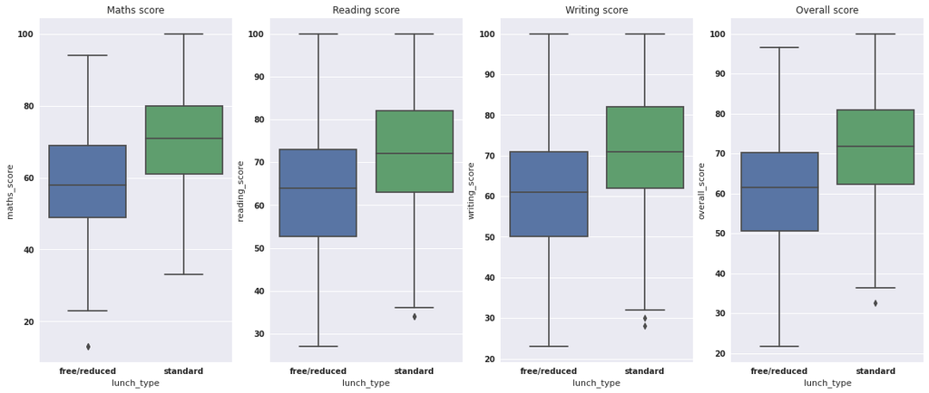

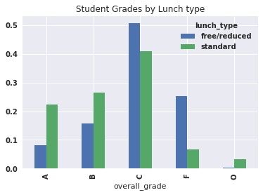

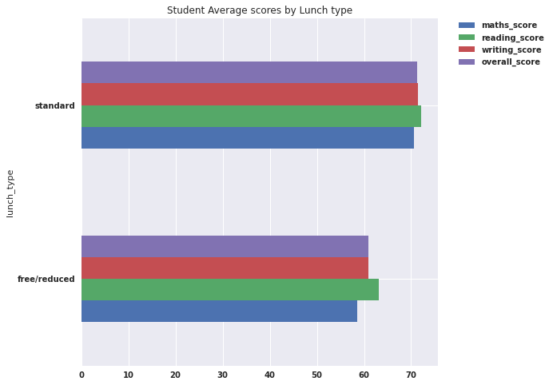

```python
# boxplot of grades by lunch type
plt.figure(figsize =(20, 8))
plt.subplot(1,4,1)
sns.boxplot(x='lunch_type', y='maths_score', data=student_grades)
plt.title("Maths score")
plt.subplot(1,4,2)
sns.boxplot(x='lunch_type', y='reading_score', data=student_grades)
plt.title("Reading score")
plt.subplot(1,4,3)
sns.boxplot(x='lunch_type', y='writing_score', data=student_grades)
plt.title("Writing score")
plt.subplot(1,4,4)
sns.boxplot(x='lunch_type', y='overall_score', data=student_grades)
plt.title("Overall score")
plt.show()

# barplot of grades by lunch type
plt.figure(figsize =(10, 4))
pd.crosstab(student_grades.overall_grade, student_grades.lunch_type, normalize="columns").plot(kind="bar")
plt.title("Student Grades by Lunch type")
plt.show()

student_grades.groupby('lunch_type').agg('mean').plot(kind='barh', figsize=(8,8))
plt.legend(bbox_to_anchor=(1.05, 1), loc=2, borderaxespad=0.)
plt.title("Student Average scores by Lunch type")
plt.show()
```

Generally student that had standard lunch had a better performance than those that had free or reduced lunch

It is very evident that food and nutriention play a vital role in the growth of a student both, physically and academically. Nutrition plays a key role in the healthy development of the children. Nutritious foods provide the body and mind with the energy needed to grow, feel well, be active, stay healthy and learn. Students are able to learn better when they're well nourished, and eating healthy meals has been linked to higher grades, better memory and alertness, and faster information processing.

Healthy students are better learners.

#### Grade Distribution by Test Preparation

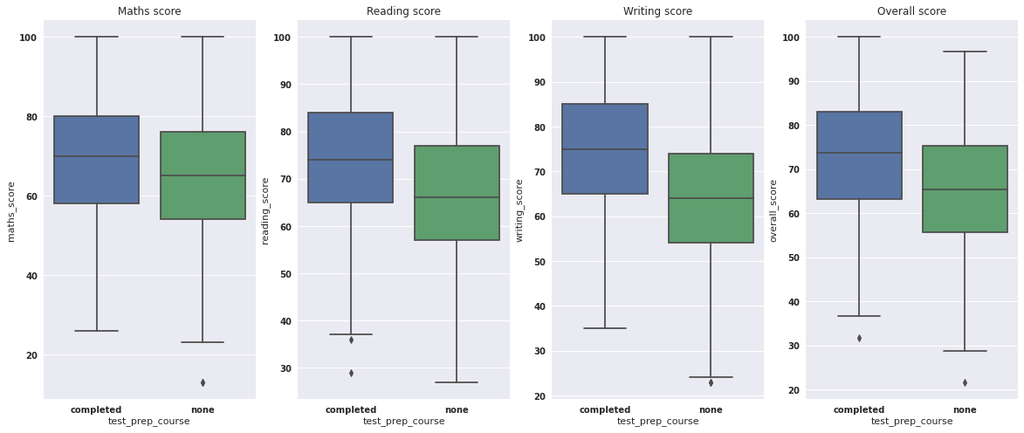

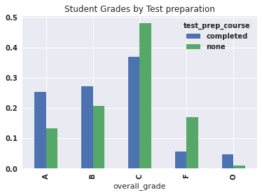

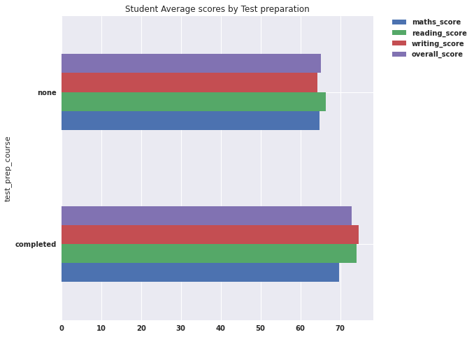

```python
# boxplot of grades by test preparation
plt.figure(figsize =(20, 8))
plt.subplot(1,4,1)
sns.boxplot(x='test_prep_course', y='maths_score', data=student_grades)
plt.title("Maths score")
plt.subplot(1,4,2)
sns.boxplot(x='test_prep_course', y='reading_score', data=student_grades)
plt.title("Reading score")
plt.subplot(1,4,3)
sns.boxplot(x='test_prep_course', y='writing_score', data=student_grades)
plt.title("Writing score")
plt.subplot(1,4,4)
sns.boxplot(x='test_prep_course', y='overall_score', data=student_grades)
plt.title("Overall score")
plt.show()

# barplot of grades by test preparation
plt.figure(figsize =(10, 4))
pd.crosstab(student_grades.overall_grade, student_grades.test_prep_course, normalize="columns").plot(kind="bar")
plt.title("Student Grades by Test preparation")
plt.show()

student_grades.groupby('test_prep_course').agg('mean').plot(kind='barh', figsize=(8,8))
plt.legend(bbox_to_anchor=(1.05, 1), loc=2, borderaxespad=0.)
plt.title("Student Average scores by Test preparation")
plt.show()
```

- Students who completed the test preparation course performed better than those that didn't complete the course.
- Those that completed the course have higher success rate while those that didn't complete the course have higher failure rate.

## 3. Conclusion

This research has shown that male students perform better in mathematics than female students, however female overall performance in mathematics, reading and writing is better than that of male. We also discovered that students from group E ethnicity had the best overall performance. We can't undermine the role of nutritious meals in the academic performance of student, which was evident in our research, as students who had standard lunch were seen to have the best performance. We also noticed that the education level of parents played a vital role in the performance of students. As the education level of parents increases, the overall performance of student also increases. Finally, the benefit of test preparation courses is shown in this research, as students who completed the course had better performance than those who didn't complete it.

In conclusion, we have seen how gender, race, parent education level, eating healthy meal, and test preparation courses play major roles when it comes to academic performance of students.